# Longitudinal MLM: Add Health

Veronica Cole

Monday, May 14, 2018

We are using data from Add Health, a nationally representative study of physical and mental health over adolescence and early adulthood. The variables are **AID** (child-level identifier); **BIO_SEX** (an indicator of the child’s biological sex); **time** (a variable indicating which wave (i.e., 1-4) the record comes from); **age** (a rescaled version of age – more on that below); **dr** (an indicator of how many times the child drank in the past month); **bi** (an indicator of binge drinking frequency); **depa-depe** (indicators of depressive symptoms, which we will not use here); **drinking** (a composite indicator of problem drinking); **dep** (a composite indicator of depressive symptoms); and **age2** (a quadratic term for age).

We load in the package **lme4**, which is the basic machinery we’ll use to fit MLMs, as well as one package to help us with plotting: **ggplot2**.

Let’s take a look at the data. Note that age certainly doesn’t look like numbers we would expect for the ages of adolescents. That is because, to facilitate convergence, it has been rescaled. First, the minimum value, 13, was subtracted; then it was divided by 10. Thus, for instance, an original age value of 19 becomes $(19-13)/10 = .6$.

```r
library(lme4)
library(ggplot2)
library(car)

add.health<-read.table("C:/Users/vcole/Dropbox/multilevel_new/add-health.dat",header=FALSE,na=".")
names(add.health)<-c("AID","BIO_SEX","time","age","dr","bi","depa","depb","depc","depd","depe","drinking","dep","age2")
```

### Linear model

First, we will fit an unconditional model in which both intercepts and slopes are allowed to vary by person. Note that we only consider linear age here – so we predict that problem drinking will increase or decrease linearly across adolescence.

```r
random.slopes<-lmer(drinking~age+(age|AID),data=add.health)
summary(random.slopes)
```

```
## Linear mixed model fit by REML ['lmerMod']
## Formula: drinking ~ age + (age | AID)
##    Data: add.health
##
## REML criterion at convergence: 74881.8
##
## Scaled residuals:
##     Min      1Q  Median      3Q     Max
## -2.6946 -0.5560 -0.2758  0.3773  4.8216
##
## Random effects:
##  Groups   Name        Variance Std.Dev. Corr
##  AID      (Intercept) 1.0630   1.031
##           age         0.8335   0.913    -0.50
##  Residual             1.7049   1.306
## Number of obs: 19973, groups: AID, 6494
##
## Fixed effects:
##             Estimate Std. Error t value
## (Intercept)  1.06775    0.02124   50.27
## age          0.41873    0.02325   18.01
##
## Correlation of Fixed Effects:
##     (Intr)
## age -0.718
```

Now, we select a random subset of fitted values to plot. Note two things. First, we use the **fitted** function to obtain fitted values. Second, when we are plotting the model-implied values, we put age back in its original scale.

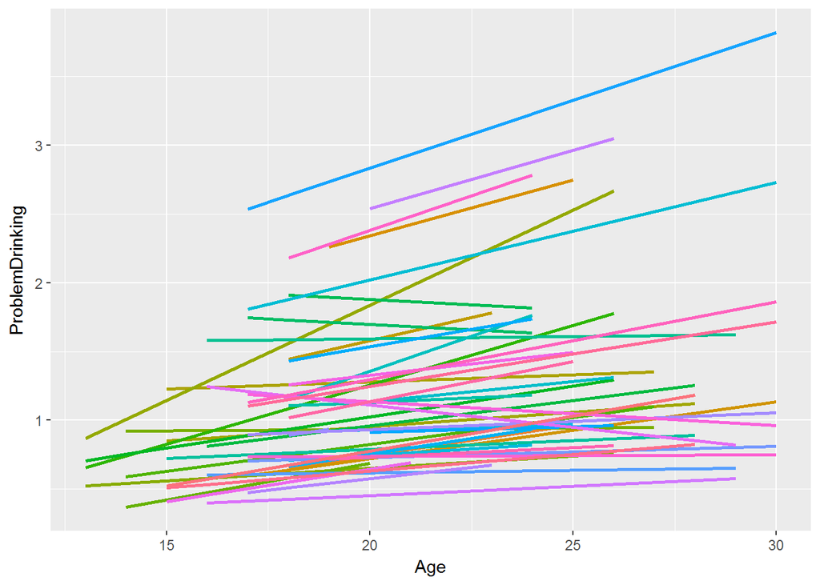

```r
fitted1<-fitted(random.slopes)

output1<-merge(fitted1,add.health,by="row.names",all.x=TRUE)
names(output1)[2]<-"ProblemDrinking"
output1<-output1[c(1:40,3001:3040,6001:6040,9001:9040),]
output1$Age<-output1$age*10+13

p1 <- ggplot(output1, aes(x = Age, y = ProblemDrinking, colour = factor(AID))) +
  geom_line(size=1) +
  theme(legend.position="none")

p1
```

### Quadratic model

```r
with.quadratic<-lmer(drinking~age+age2+BIO_SEX+BIO_SEX:age+(age|AID),data=add.health)
summary(with.quadratic)
```

```
## Linear mixed model fit by REML ['lmerMod']
## Formula: drinking ~ age + age2 + BIO_SEX + BIO_SEX:age + (age | AID)
##    Data: add.health
##
## REML criterion at convergence: 74302.1
##
## Scaled residuals:
##     Min      1Q  Median      3Q     Max
## -2.8381 -0.5713 -0.2157  0.3919  4.8115
##
## Random effects:
##  Groups   Name        Variance Std.Dev. Corr
##  AID      (Intercept) 0.9677   0.9837
##           age         0.6846   0.8274   -0.46
##  Residual             1.6828   1.2972
## Number of obs: 19973, groups: AID, 6494
##
## Fixed effects:
##             Estimate Std. Error t value
## (Intercept)  0.66079    0.03643  18.141
## age          1.79676    0.08753  20.528
## age2        -0.94963    0.04798 -19.791
## BIO_SEX     -0.10978    0.04153  -2.643
## age:BIO_SEX  0.54359    0.04512  12.048
##
## Correlation of Fixed Effects:
##             (Intr) age    age2   BIO_SE
## age         -0.775
## age2         0.621 -0.937
## BIO_SEX     -0.533  0.162  0.009
## age:BIO_SEX  0.373 -0.232 -0.006 -0.710
```

```r
anova(with.quadratic,random.slopes)
```

```
## Data: add.health
## Models:
## random.slopes: drinking ~ age + (age | AID)
## with.quadratic: drinking ~ age + age2 + BIO_SEX + BIO_SEX:age + (age | AID)
##                Df   AIC   BIC logLik deviance  Chisq Chi Df Pr(>Chisq)
## random.slopes   6 74882 74929 -37435    74870
## with.quadratic  9 74294 74365 -37138    74276 593.58      3  < 2.2e-16 ***
## ---
## Signif. codes:  0 '***' 0.001 '**' 0.01 '*' 0.05 '.' 0.1 ' ' 1
```

Finally, as before, we plot fitted values.

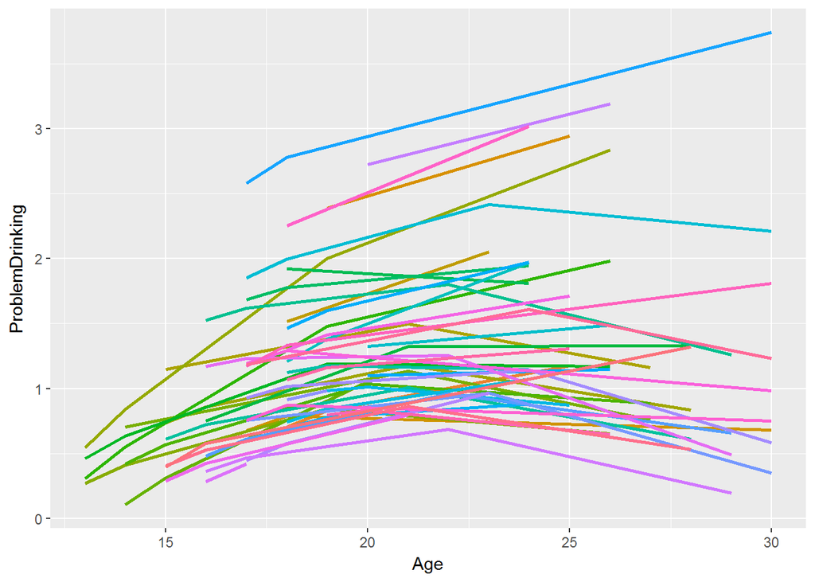

```r
fitted2<-fitted(with.quadratic)

output2<-merge(fitted2,add.health,by="row.names",all.x=TRUE)
names(output2)[2]<-"ProblemDrinking"
output2<-output2[c(1:40,3001:3040,6001:6040,9001:9040),]
output2$Age<-output2$age*10+13

p2 <- ggplot(output2, aes(x = Age, y = ProblemDrinking, colour = factor(AID))) +
  geom_line(size=1) +
  theme(legend.position="none")
p2
```

### Adding predictors

First, we add in a time-invariant predictor: **BIO_SEX**. This will help us test the hypotheses that (1) boys show higher levels of problem drinking overall than girls; and (2) boys’ problem drinking increases at a faster rate than girls’. We see, using the **anova** function, that adding in **BIO_SEX** explains a significant amount of variance in problem drinking.

```r
slopes.as.outcomes<-lmer(drinking~age+BIO_SEX+BIO_SEX:age+(age|AID),data=add.health)
summary(slopes.as.outcomes)
```

```
## Linear mixed model fit by REML ['lmerMod']
## Formula: drinking ~ age + BIO_SEX + BIO_SEX:age + (age | AID)
##    Data: add.health
##
## REML criterion at convergence: 74682.6
##
## Scaled residuals:
##     Min      1Q  Median      3Q     Max
## -2.6257 -0.5567 -0.2839  0.3825  4.8431
##
## Random effects:
##  Groups   Name        Variance Std.Dev. Corr
##  AID      (Intercept) 1.056    1.0278
##           age         0.769    0.8769   -0.51
##  Residual             1.704    1.3054
## Number of obs: 19973, groups: AID, 6494
##
## Fixed effects:
##             Estimate Std. Error t value
## (Intercept)  1.11090    0.02920   38.04
## age          0.17167    0.03126    5.49
## BIO_SEX     -0.10128    0.04245   -2.39
## age:BIO_SEX  0.53762    0.04605   11.68
##
## Correlation of Fixed Effects:
##             (Intr) age    BIO_SE
## age         -0.719
## BIO_SEX     -0.688  0.494
## age:BIO_SEX  0.488 -0.679 -0.721
```

```r
anova(slopes.as.outcomes,random.slopes)
```

```
## Data: add.health
## Models:
## random.slopes: drinking ~ age + (age | AID)
## slopes.as.outcomes: drinking ~ age + BIO_SEX + BIO_SEX:age + (age | AID)
##                    Df   AIC   BIC logLik deviance  Chisq Chi Df Pr(>Chisq)
## random.slopes       6 74882 74929 -37435    74870
## slopes.as.outcomes  8 74677 74740 -37330    74661 208.76      2  < 2.2e-16
##
## random.slopes
## slopes.as.outcomes ***
## ---
## Signif. codes:  0 '***' 0.001 '**' 0.01 '*' 0.05 '.' 0.1 ' ' 1
```

Finally, we add in time-varying depressive symptoms as a predictor. Note that we can’t make too many inferences about the relationship between depressive symptoms and problem drinking, because the two are measured contemporaneously.

```r
with.depression<-lmer(drinking~age+BIO_SEX+dep+BIO_SEX:age+(age|AID),data=add.health)
summary(with.depression)
```

```
## Linear mixed model fit by REML ['lmerMod']
## Formula: drinking ~ age + BIO_SEX + dep + BIO_SEX:age + (age | AID)
##    Data: add.health
##
## REML criterion at convergence: 71881.2
##
## Scaled residuals:
##     Min      1Q  Median      3Q     Max
## -2.5823 -0.5492 -0.2230  0.3572  5.5373
##
## Random effects:
##  Groups   Name        Variance Std.Dev. Corr
##  AID      (Intercept) 0.5759   0.7589
##           age         0.6079   0.7797   -0.35
##  Residual             1.5736   1.2544
## Number of obs: 19939, groups: AID, 6490
##
## Fixed effects:
##             Estimate Std. Error t value
## (Intercept) 0.362826   0.028963   12.53
## age         0.279140   0.029391    9.50
## BIO_SEX     0.080281   0.037444    2.14
## dep         0.300892   0.005539   54.32
## age:BIO_SEX 0.457861   0.043277   10.58
##
## Correlation of Fixed Effects:
##             (Intr) age    BIO_SE dep
## age         -0.649
## BIO_SEX     -0.647  0.486
## dep         -0.468  0.060  0.093
## age:BIO_SEX  0.439 -0.679 -0.707 -0.037
```